# Analysis of Streaming Transactions

Based on Data Collected by SportsTV Germany

Karthik Bharadwaj and Akshay Mambakkam Sridharan

December 08, 2025

# 1 Data Breakdown

This report presents a comprehensive analysis of streaming transaction data for SportsTV Germany, a platform specializing in the distribution of amateur sporting event recordings. The dataset spans **2021-01-06** through **2025-10-16**, representing comprehensive platform activity stored in a **dimensional data warehouse** with partitioned fact tables.

# 2 Growth of streaming transactions by streaming time and number of streaming events by sport

This analysis covers a **5-year period** of streaming activity, with data collected from **2021** through **2025**.

## 2.1 Growth in Streaming Events by Sport

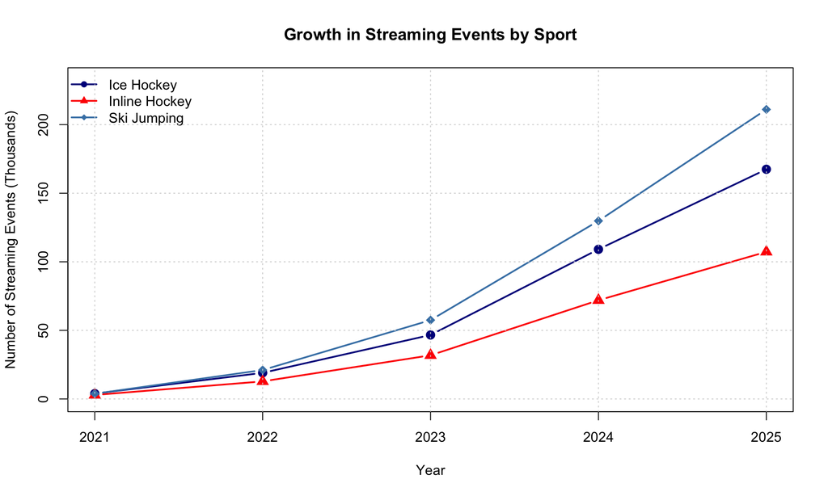

## 2.2 Growth in Streaming Time by Sport

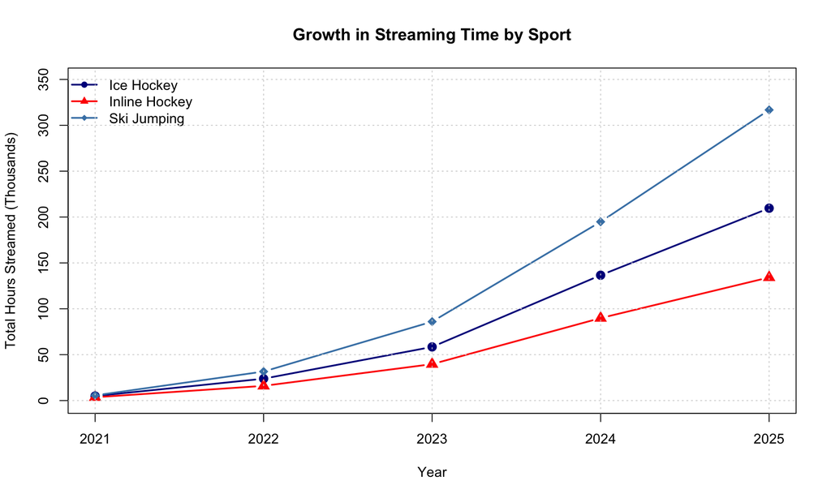

## 2.3 Year-over-Year Growth Summary

Streaming Transactions by Sport and Year

|  | Year | Ice Hockey | Inline Hockey | Ski Jumping | Total |
| --- | --- | --- | --- | --- | --- |
| 1 | 2,021 | 3,892 | 2,905 | 3,801 | 10,598 |
| 4 | 2,022 | 19,031 | 12,809 | 21,088 | 52,928 |
| 7 | 2,023 | 46,650 | 31,835 | 57,461 | 135,946 |
| 10 | 2,024 | 109,087 | 71,949 | 129,819 | 310,855 |
| 13 | 2,025 | 167,445 | 107,259 | 211,060 | 485,764 |

**Key Findings:** The data reveals that **Ski Jumping** is the most popular sport on the platform, accounting for **423,229** transactions. Streaming activity peaked in **2025** with **485,764** transactions recorded.

# 3 Number of streaming events per week for the most recent year

## 3.1 Weekly Transaction Volume

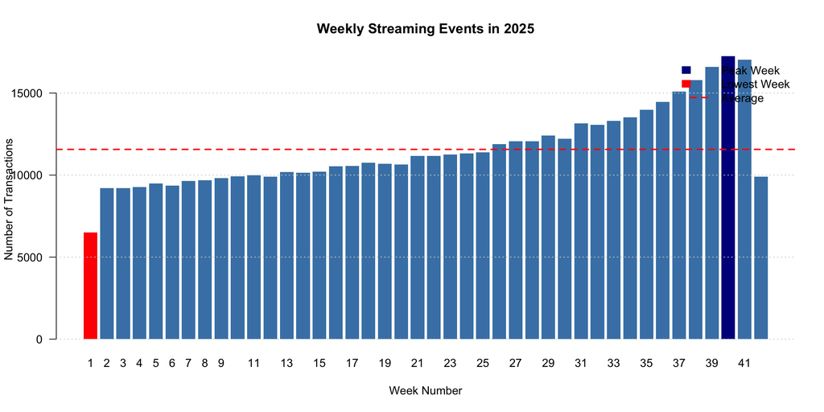

In **2025**, the platform recorded **485,764** streaming events totaling **660,614** hours across **42 weeks**. Weekly transactions averaged **11,566**, peaking at **17,240** in week **40** and dropping to **6,509** in week **1**.

## 3.2 Weekly Statistics Summary

Weekly Streaming Statistics for 2025

| Metric | Value |
| --- | --- |
| Average Weekly Transactions | 11,566 |
| Peak Week | 40 |
| Peak Week Transactions | 17,240 |
| Lowest Week | 1 |
| Lowest Week Transactions | 6,509 |
| Week-to-Week Variance | 20.4% |

# 4 Average streaming time and total number of streams by sport and by country

## 4.1 Average Streaming Duration by Sport and Country

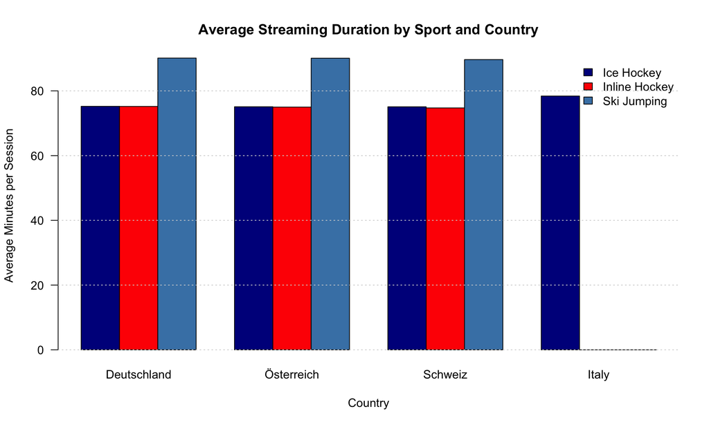

## 4.2 Total Streams by Sport and Country

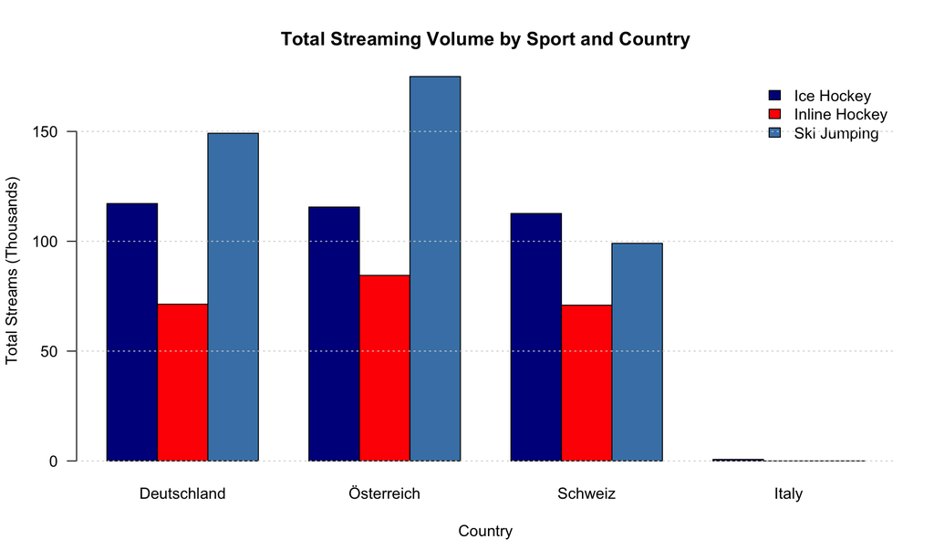

## 4.3 Detailed Statistics Table

Streaming Statistics by Sport and Country

| Sport | Country | Total Streams | Avg Duration (min) | Total Hours |
| --- | --- | --- | --- | --- |
| Ice Hockey | Deutschland | 117,178 | 75.2 | 146,910 |
| Ice Hockey | Österreich | 115,591 | 75.1 | 144,667 |
| Ice Hockey | Schweiz | 112,644 | 75.1 | 140,954 |
| Ice Hockey | Italy | 692 | 78.4 | 904 |
| Inline Hockey | Österreich | 84,485 | 75.0 | 105,601 |
| Inline Hockey | Deutschland | 71,358 | 75.2 | 89,434 |
| Inline Hockey | Schweiz | 70,914 | 74.7 | 88,330 |
| Ski Jumping | Österreich | 174,997 | 90.1 | 262,744 |
| Ski Jumping | Deutschland | 149,157 | 90.1 | 224,059 |
| Ski Jumping | Schweiz | 99,075 | 89.7 | 148,059 |

# 5 Day of the week during which the most amount of content is streamed

This section analyzes which days of the week generate the most streaming activity, aggregated over the past three years by sport and country.

Analysis period: **2023** to **2025** (3 years)

## 5.1 Overall Day of Week Patterns

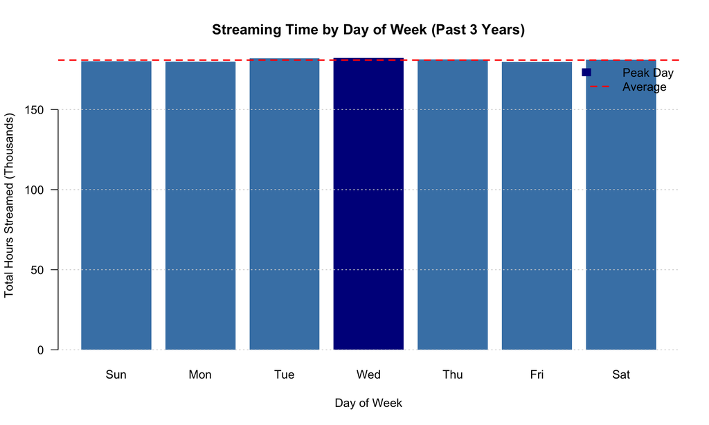

**Peak Streaming Day:** Wed with 182,126 total hours streamed over the past three years.

## 5.2 Day of Week by Sport

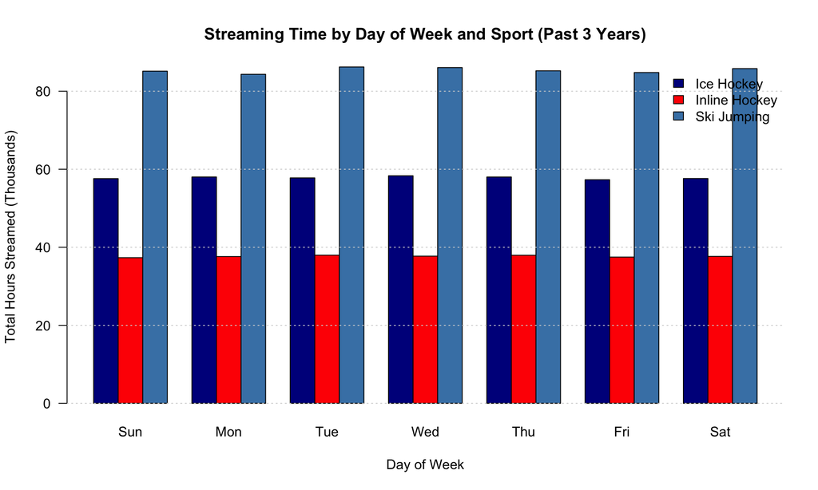

## 5.3 Day of Week by Country

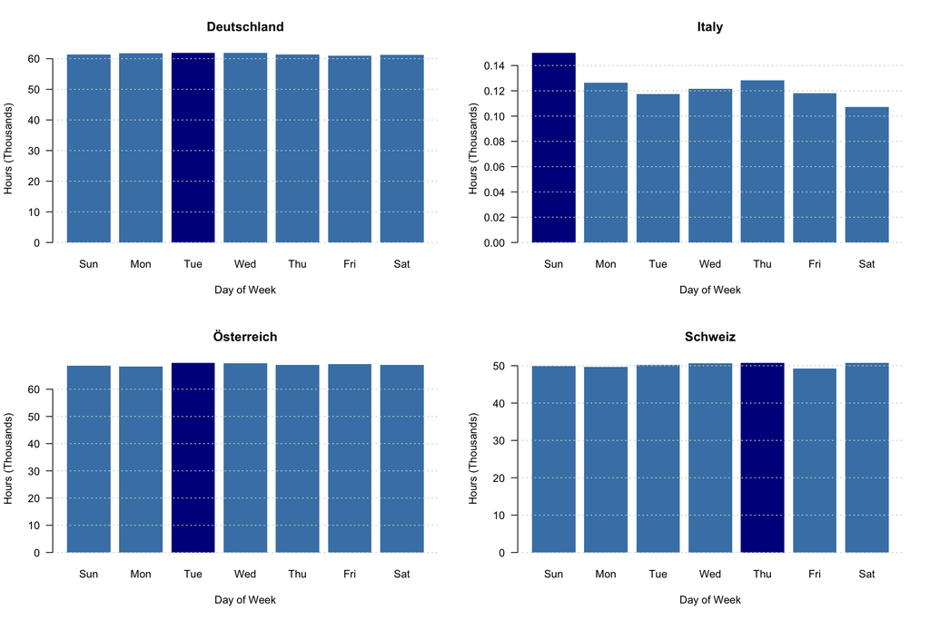

## 5.4 Peak Day Summary by Sport and Country

Peak Streaming Day by Sport and Country (Past 3 Years)

|  | Sport | Country | Peak Day | Total Hours |
| --- | --- | --- | --- | --- |
| 5 | Ice Hockey | Österreich | Fri | 19,846 |
| 1 | Ice Hockey | Deutschland | Mon | 19,704 |
| 8 | Ice Hockey | Schweiz | Sat | 19,157 |
| 4 | Ice Hockey | Italy | Sun | 150 |
| 6 | Inline Hockey | Österreich | Tue | 14,326 |
| 2 | Inline Hockey | Deutschland | Mon | 12,092 |
| 9 | Inline Hockey | Schweiz | Thu | 11,806 |
| 7 | Ski Jumping | Österreich | Sat | 35,865 |
| 3 | Ski Jumping | Deutschland | Tue | 30,617 |
| 10 | Ski Jumping | Schweiz | Thu | 19,987 |

# 6 Device and Quality Analysis

## 6.1 Streaming by Device Type

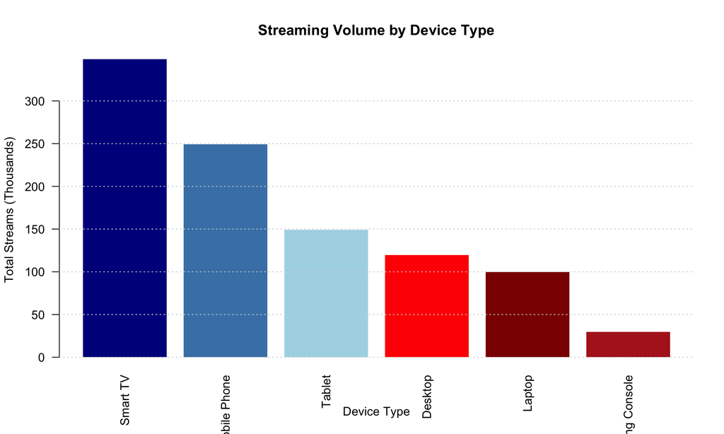

Streaming Statistics by Device Type

| Device Type | Total Streams | Avg Duration (min) | Total Hours | % Share |
| --- | --- | --- | --- | --- |
| Smart TV | 348,690 | 81.4 | 472,900 | 35 |
| Mobile Phone | 249,130 | 81.4 | 337,884 | 25 |
| Tablet | 149,134 | 81.5 | 202,651 | 15 |
| Desktop | 119,537 | 81.5 | 162,350 | 12 |
| Laptop | 99,911 | 81.4 | 135,591 | 10 |
| Gaming Console | 29,689 | 81.4 | 40,286 | 3 |

## 6.2 Streaming by Quality

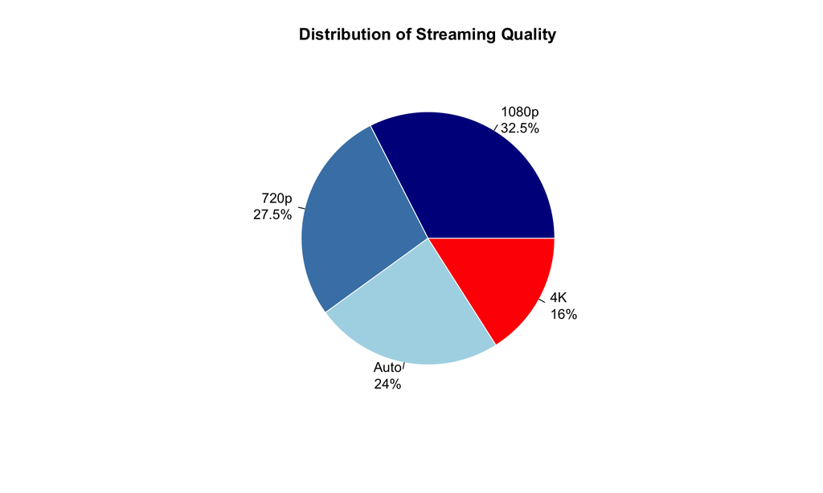

Streaming Statistics by Quality Level

| Quality Level | Total Streams | Total Hours | % Share |
| --- | --- | --- | --- |
| 1080p | 323,857 | 439,515 | 32.5 |
| 720p | 273,705 | 371,392 | 27.5 |
| Auto | 239,233 | 324,704 | 24.0 |
| 4K | 159,296 | 216,052 | 16.0 |